# Script to validate points in ReSurvey database using RS data

Adding ATL_BENELUX and CON_NORDIC S2 data, some Landsat data, adding canopy height data

Alicia Valdés

25 marzo 2025

This R script is used to validate the points in the ReSurvey database using RS indicators (NDVI, NDMI, canopy height).

# Load libraries

```r
library(tidyverse)
library(here)
library(gridExtra)
library(readxl)
library(scales)
library(sf)
library(rnaturalearth)
```

# Define printall function

```r
printall <- function(tibble) {
  print(tibble, width = Inf)
  }
```

# Read ReSurvey data with RS indicators

```r
db_resurv_RS<-read_tsv(
  here("data", "clean", "db_resurv_RS_20250318.csv"),
  col_types = cols(
    # Dynamically specify EUNIS columns as character
    .default = col_guess(),  # Default guessing for other columns
    EUNISa = col_character(),
    EUNISb = col_character(),
    EUNISc = col_character(),
    EUNISd = col_character(),
    EUNISa_1 = col_character(),
    EUNISa_2 = col_character(),
    EUNISa_3 = col_character(),
    EUNISa_4 = col_character(),
    EUNISb_1 = col_character(),
    EUNISb_2 = col_character(),
    EUNISb_3 = col_character(),
    EUNISb_4 = col_character(),
    EUNISc_1 = col_character(),
    EUNISc_2 = col_character(),
    EUNISc_3 = col_character(),
    EUNISc_4 = col_character(),
    EUNISd_1 = col_character(),
    EUNISd_2 = col_character(),
    EUNISd_3 = col_character(),
    EUNISd_4 = col_character(),
    EUNISa_1_descr = col_character(),
    EUNISb_1_descr = col_character(),
    EUNISc_1_descr = col_character(),
    EUNISd_1_descr = col_character(),
    EUNIS_assignation = col_character(),
    EUNISa_2_descr = col_character(),
    EUNISa_3_descr = col_character(),
    EUNISa_4_descr = col_character(),
    EUNISb_2_descr = col_character(),
    EUNISb_3_descr = col_character(),
    EUNISb_4_descr = col_character(),
    EUNISc_2_descr = col_character(),
    EUNISc_3_descr = col_character(),
    EUNISc_4_descr = col_character(),
    EUNISd_2_descr = col_character(),
    EUNISd_3_descr = col_character(),
    EUNISd_4_descr = col_character()
    )
  )
```

No parsing issues!

# Several EUNIS level 1 assigned

Number of rows where there is more than one EUNIS 1 assigned, and they are different among them. See what to do with these later! So far I take EUNISa_1.

```r
nrow(db_resurv_RS %>%
       # Rows with more than one EUNIS 1 assigned
       filter(!is.na(EUNISb_1)) %>%
       filter(EUNISa_1!=EUNISb_1 | EUNISb_1 != EUNISc_1 | EUNISa_1 != EUNISc_1))
```

```
[1] 102
```

# Tibble with selected columns

```r
db_resurv_RS_short <- db_resurv_RS %>%
  select(PlotObservationID, Country, RS_CODE, `ReSurvey site`, `ReSurvey plot`,
         `Manipulate (y/n)`, `Type of manipulation`, Lon_updated, Lat_updated,
         `Location method`, `Location uncertainty (m)`, EUNISa_1,
         EUNISa_1_descr, EUNISa_2, EUNISa_2_descr, EUNISa_3, EUNISa_3_descr,
         EUNISa_4, EUNISa_4_descr, date, year, biogeo, unit, year_RS, Lon_RS,
         Lat_RS, NDVI_S2, NDMI_S2, NDVI_Landsat, NDMI_Landsat, NDVI, NDMI,
         canopy_height, S2_data, Landsat_data, CH_data)
```

# Missing data checks

Do when all RS data is ready!

# Flag when year is different between RS data and ReSurvey db

```r
db_resurv_RS_short <- db_resurv_RS_short %>%
  mutate(year_diff = year != year_RS)
```

```r
db_resurv_RS_short %>% count(year_diff)
```

| year_diff | n |
| --- | --- |
| FALSE | 74992 |
| TRUE | 2 |
| NA | 348977 |

2 with different year. NDVI and NDMI would need to be calculated again for those.

# Flag when coordinates are different between RS data and ReSurvey db

```r
db_resurv_RS_short <- db_resurv_RS_short %>%
  mutate(Lon_diff = case_when(Lon_updated == Lon_RS ~ "NO",
                              # Sometimes they are only slighly different
                              abs(Lon_updated - Lon_RS) < 0.01 ~ "SMALL",
                              is.na(Lon_updated) | is.na(Lon_RS) ~ NA,
                              TRUE ~ "LARGE"),
         Lat_diff = case_when(Lat_updated == Lat_RS ~ "NO",
                              # Sometimes they are only slighly different
                              abs(Lat_updated - Lat_RS) < 0.01 ~ "SMALL",
                              is.na(Lat_updated) | is.na(Lat_RS) ~ NA,
                              TRUE ~ "LARGE"))
```

```r
db_resurv_RS_short %>% count(Lon_diff)
```

| Lon_diff | n |
| --- | --- |
| LARGE | 4 |
| NO | 74715 |
| SMALL | 275 |
| NA | 348977 |

```r
db_resurv_RS_short %>% count(Lat_diff)
```

| Lat_diff | n |
| --- | --- |
| LARGE | 6 |
| NO | 25433 |
| SMALL | 49555 |
| NA | 348977 |

Very few with large differences (4 for longitude, 6 for latitude). NDVI and NDMI would need to be calculated again for those.

If year_diff is TRUE or Lon_diff is LARGE or Lat_diff is LARGE –> NDVI and NDMI need to be recalculated. So far, remove those rows from db_resurv_RS_short.

```r
db_resurv_RS_short <- db_resurv_RS_short %>%
  filter(year_diff == FALSE | is.na(year_diff)) %>%
  filter(Lon_diff == "NO" |Lon_diff == "SMALL" | is.na(Lon_diff)) %>%
  filter(Lat_diff == "NO" |Lat_diff == "SMALL" | is.na(Lat_diff))
```

# Distributions all bioregions

Violin + boxplot + points.

## NDVI

```r
source("https://gist.githubusercontent.com/benmarwick/2a1bb0133ff568cbe28d/raw/fb53bd97121f7f9ce947837ef1a4c65a73bffb3f/geom_flat_violin.R")
```

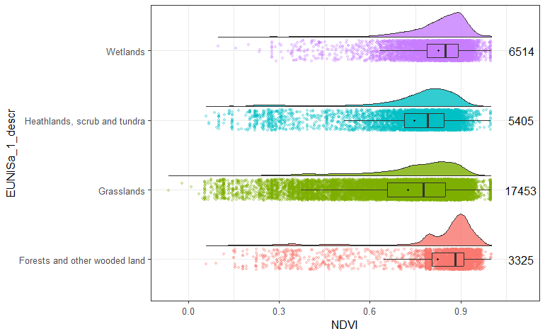

```r
ggplot(data = db_resurv_RS_short %>%
         # Keep only forests, grasslands, shrublands and wetlands
         filter(EUNISa_1 %in% c("T", "R", "S", "Q")),
       aes(x = EUNISa_1_descr, y = NDVI, fill = EUNISa_1_descr)) +
  geom_flat_violin(position = position_nudge(x = 0.2, y = 0), alpha = 0.8) +
  geom_point(aes(y = NDVI, color = EUNISa_1_descr),
             position = position_jitter(width = 0.15), size = 1, alpha = 0.25) +
  geom_boxplot(width = 0.2, outlier.shape = NA, alpha = 0.5) +
  stat_summary(fun.y=mean, geom="point", shape = 20, size = 1) +
  stat_summary(fun.data = function(x) data.frame(y = max(x) + 0.1,
                                                 label = length(x)),
               geom = "text", aes(label = ..label..), vjust = 0.5) +
  labs(y = "NDVI", x = "EUNISa_1_descr") +
  guides(fill = FALSE, color = FALSE) +
  theme_bw() + coord_flip()
ggsave(
  here("output", "figures", "NDVI.tiff"),
  width = 21, height = 29.7, units = "cm", dpi = 300)
```

## NDMI

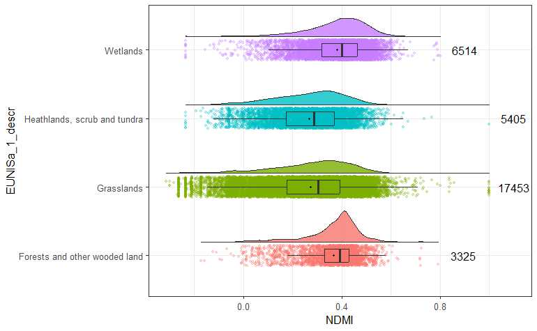

```r
ggplot(data = db_resurv_RS_short %>%
         # Keep only forests, grasslands, shrublands and wetlands
         filter(EUNISa_1 %in% c("T", "R", "S", "Q")),
       aes(x = EUNISa_1_descr, y = NDMI, fill = EUNISa_1_descr)) +
  geom_flat_violin(position = position_nudge(x = 0.2, y = 0), alpha = 0.8) +
  geom_point(aes(y = NDMI, color = EUNISa_1_descr),
             position = position_jitter(width = 0.15), size = 1, alpha = 0.25) +
  geom_boxplot(width = 0.2, outlier.shape = NA, alpha = 0.5) +
  stat_summary(fun.y=mean, geom="point", shape = 20, size = 1) +
  stat_summary(fun.data = function(x) data.frame(y = max(x) + 0.1,
                                                 label = length(x)),
               geom = "text", aes(label = ..label..), vjust = 0.5) +
  labs(y = "NDMI", x = "EUNISa_1_descr") +
  guides(fill = FALSE, color = FALSE) +
  theme_bw() + coord_flip()
ggsave(
  here("output", "figures", "NDMI.tiff"),
  width = 21, height = 29.7, units = "cm", dpi = 300)
```

## CH

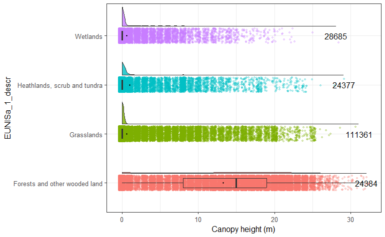

```r
ggplot(data = db_resurv_RS_short %>%
         # Keep only forests, grasslands, shrublands and wetlands
         filter(EUNISa_1 %in% c("T", "R", "S", "Q")),
       aes(x = EUNISa_1_descr, y = canopy_height, fill = EUNISa_1_descr)) +
  geom_flat_violin(position = position_nudge(x = 0.2, y = 0), alpha = 0.8) +
  geom_point(aes(y = canopy_height, color = EUNISa_1_descr),
             position = position_jitter(width = 0.15), size = 1, alpha = 0.25) +
  geom_boxplot(width = 0.2, outlier.shape = NA, alpha = 0.5) +
  stat_summary(fun.y=mean, geom="point", shape = 20, size = 1) +
  stat_summary(fun.data = function(x) data.frame(y = max(x) + 0.1,
                                                 label = length(x)),
               geom = "text", aes(label = ..label..), vjust = 0.5) +
  labs(y = "Canopy height (m)", x = "EUNISa_1_descr") +
  guides(fill = FALSE, color = FALSE) +
  theme_bw() + coord_flip()
ggsave(
  here("output", "figures", "CH.tiff"),
  width = 21, height = 29.7, units = "cm", dpi = 300)
```

### Show habitats of points with low CH

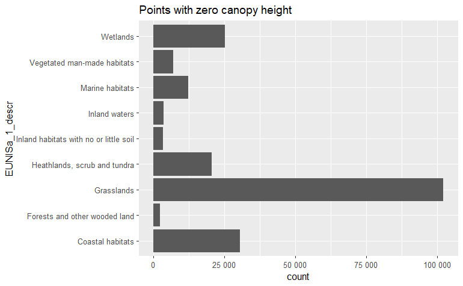

```r
ggplot(db_resurv_RS_short %>%
         filter(!is.na(EUNISa_1_descr) & canopy_height == 0),
       aes(x = EUNISa_1_descr)) +
  geom_bar() + coord_flip() +
  scale_y_continuous(labels = label_number()) +
ggtitle("Points with zero canopy height")
```

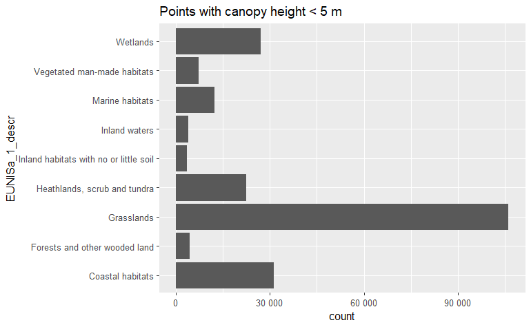

```r
ggplot(db_resurv_RS_short %>%
         filter(!is.na(EUNISa_1_descr) & canopy_height < 5),
       aes(x = EUNISa_1_descr)) +
  geom_bar() + coord_flip() +
  scale_y_continuous(labels = label_number()) +
ggtitle("Points with canopy height < 5 m")
```

### Show habitats with CH categories

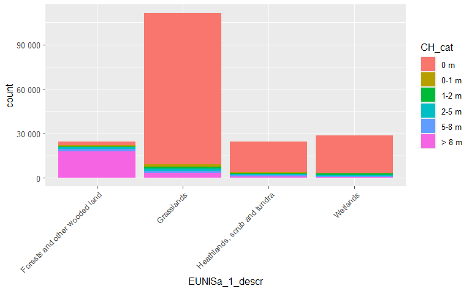

```r
ggplot(db_resurv_RS_short %>%
         # Keep only forests, grasslands, shrublands and wetlands
         filter(EUNISa_1 %in% c("T", "R", "S", "Q")) %>%
         mutate(CH_cat =
                  factor(
                    case_when(canopy_height == 0 ~ "0 m",
                              canopy_height > 0 & canopy_height <= 1 ~ "0-1 m",
                              canopy_height > 1 & canopy_height <=2 ~ "1-2 m",
                              canopy_height > 2 & canopy_height <=5 ~ "2-5 m",
                              canopy_height > 5 & canopy_height <=8 ~ "5-8 m",
                              canopy_height > 8 ~ "> 8 m",
                              is.na(canopy_height) ~ NA_character_),
                    levels = c(
                      "0 m", "0-1 m", "1-2 m", "2-5 m", "5-8 m", "> 8 m"))),
       aes(x = EUNISa_1_descr, fill = CH_cat)) +
  geom_bar() +
  scale_y_continuous(labels = label_number()) +
  theme(axis.text.x = element_text(angle = 45, hjust = 1))
ggsave(
  here("output", "figures", "CH_cats_habs.tiff"),
  width = 18, height = 18, units = "cm", dpi = 300)
```

### Stats per habitat type

```r
db_resurv_RS_short %>%
  # Keep only forests, grasslands, shrublands and wetlands
  filter(EUNISa_1 %in% c("T", "R", "S", "Q")) %>%
  group_by(EUNISa_1_descr) %>%
  summarise(across(canopy_height, list(
    mean = mean,
    median = median,
    sd = sd,
    min = min,
    max = max
    ), na.rm = TRUE))
```

| EUNISa_1_descr | canopy_height_mean | canopy_height_median | canopy_height_sd | canopy_height_min | canopy_height_max |
| --- | --- | --- | --- | --- | --- |
| Forests and other wooded land | 13.2871145 | 15 | 7.423627 | 0 | 32 |
| Grasslands | 0.5925683 | 0 | 2.624805 | 0 | 31 |
| Heathlands, scrub and tundra | 0.9856832 | 0 | 3.078158 | 0 | 29 |
| Wetlands | 0.6209866 | 0 | 2.229834 | 0 | 28 |

# Distributions per bioregion

## NDVI

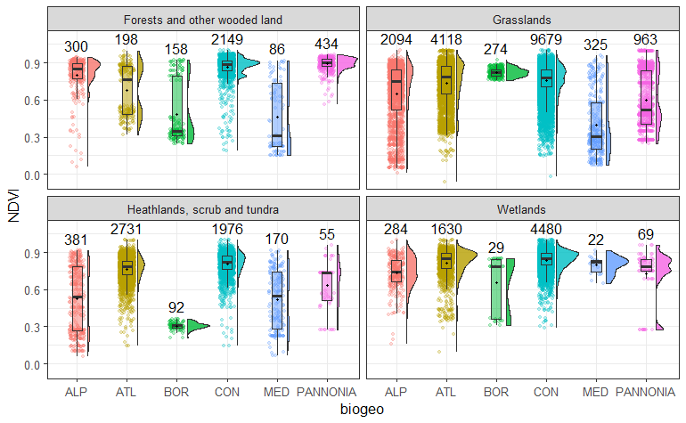

```r
ggplot(data = db_resurv_RS_short %>%
         # Keep only forests, grasslands, shrublands and wetlands
         filter(EUNISa_1 %in% c("T", "R", "S", "Q")) %>%
         filter(S2_data == T | Landsat_data == T ),
       aes(x = biogeo, y = NDVI, fill = biogeo)) +
  facet_wrap(~ EUNISa_1_descr) +
  geom_flat_violin(position = position_nudge(x = 0.2, y = 0), alpha = 0.8) +
  geom_point(aes(y = NDVI, color = biogeo),
             position = position_jitter(width = 0.15), size = 1, alpha = 0.25) +
  geom_boxplot(width = 0.2, outlier.shape = NA, alpha = 0.5) +
  stat_summary(fun.y=mean, geom="point", shape = 20, size = 1) +
  stat_summary(fun.data = function(x) data.frame(y = max(x) + 0.1,
                                                 label = length(x)),
               geom = "text", aes(label = ..label..), vjust = 0.5) +
  labs(y = "NDVI", x = "biogeo") +
  guides(fill = FALSE, color = FALSE) +
  theme_bw()
ggsave(
  here("output", "figures", "NDVI_biogeo.tiff"),
  width = 29.7, height = 21, units = "cm", dpi = 300)
```

## NDMI

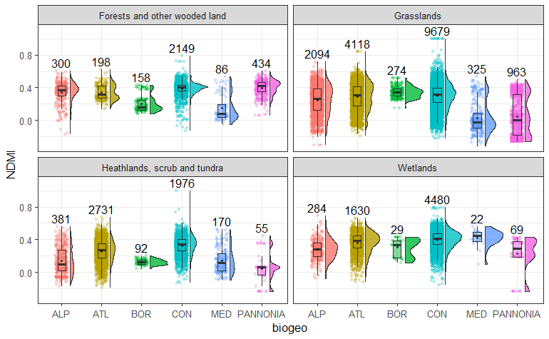

```r
ggplot(data = db_resurv_RS_short %>%
         # Keep only forests, grasslands, shrublands and wetlands
         filter(EUNISa_1 %in% c("T", "R", "S", "Q")) %>%
         filter(S2_data == T | Landsat_data == T ),
       aes(x = biogeo, y = NDMI, fill = biogeo)) +
  facet_wrap(~ EUNISa_1_descr) +
  geom_flat_violin(position = position_nudge(x = 0.2, y = 0), alpha = 0.8) +
  geom_point(aes(y = NDMI, color = biogeo),
             position = position_jitter(width = 0.15), size = 1, alpha = 0.25) +
  geom_boxplot(width = 0.2, outlier.shape = NA, alpha = 0.5) +
  stat_summary(fun.y=mean, geom="point", shape = 20, size = 1) +
  stat_summary(fun.data = function(x) data.frame(y = max(x) + 0.1,
                                                 label = length(x)),
               geom = "text", aes(label = ..label..), vjust = 0.5) +
  labs(y = "NDMI", x = "biogeo") +
  guides(fill = FALSE, color = FALSE) +
  theme_bw()
ggsave(
  here("output", "figures", "NDMI_biogeo.tiff"),
  width = 29.7, height = 21, units = "cm", dpi = 300)
```

## CH

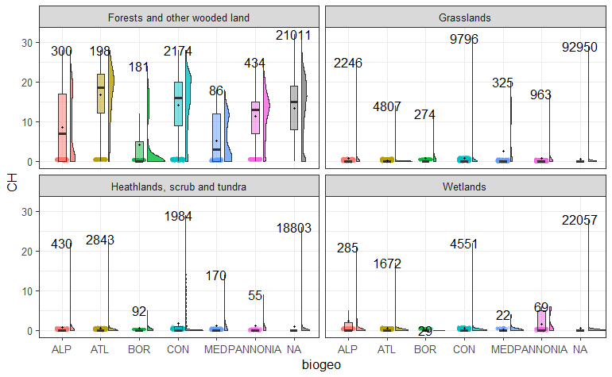

```r
ggplot(data = db_resurv_RS_short %>%
         # Keep only forests, grasslands, shrublands and wetlands
         filter(EUNISa_1 %in% c("T", "R", "S", "Q")) %>%
         filter(CH_data == T),
       aes(x = biogeo, y = canopy_height, fill = biogeo)) +
  facet_wrap(~ EUNISa_1_descr) +
  geom_flat_violin(position = position_nudge(x = 0.2, y = 0), alpha = 0.8) +
  geom_point(aes(y = NDMI, color = biogeo),
             position = position_jitter(width = 0.15), size = 1, alpha = 0.25) +
  geom_boxplot(width = 0.2, outlier.shape = NA, alpha = 0.5) +
  stat_summary(fun.y=mean, geom="point", shape = 20, size = 1) +
  stat_summary(fun.data = function(x) data.frame(y = max(x) + 0.1,
                                                 label = length(x)),
               geom = "text", aes(label = ..label..), vjust = 0.5) +
  labs(y = "CH", x = "biogeo") +
  guides(fill = FALSE, color = FALSE) +
  theme_bw()
ggsave(
  here("output", "figures", "CH_biogeo.tiff"),
  width = 29.7, height = 21, units = "cm", dpi = 300)
```

In this plot, those with biogeo = NA are those that do not have S2 or Landsat data (and thus biogeo has not been assigned), but have CH data. We should later assign a biogeo based on location.

# Comparison GPS vs. no GPS points

### NDVI

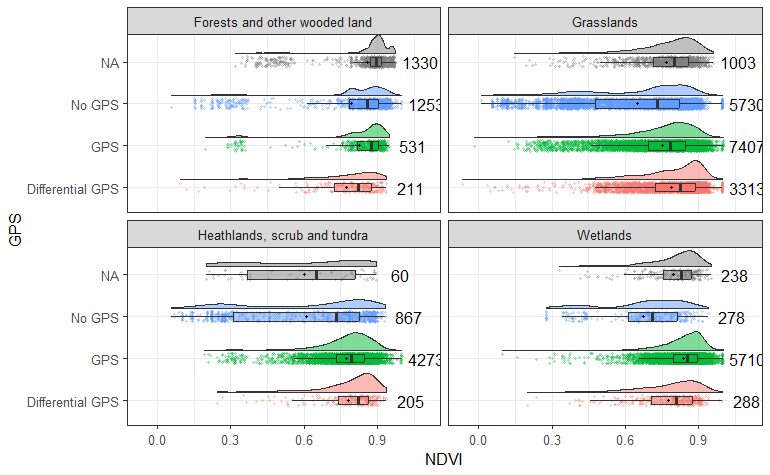

```r
ggplot(data = db_resurv_RS_short %>%
         # Keep only forests, grasslands, shrublands and wetlands
         filter(EUNISa_1 %in% c("T", "R", "S", "Q")) %>%
         filter(S2_data == T | Landsat_data == T ) %>%
         mutate(GPS = ifelse(
           `Location method` == "Location with differential GPS",
           "Differential GPS",
           ifelse(`Location method` == "Location with GPS", "GPS",
                  "No GPS"))),
       aes(x = GPS, y = NDVI, fill = GPS)) +
  geom_flat_violin(position = position_nudge(x = 0.2, y = 0), alpha = 0.5) +
  geom_point(aes(y = NDVI, color = GPS),
             position = position_jitterdodge(jitter.width = 0.25,
                                             dodge.width = 0.25),
             size = 0.5, alpha = 0.25) +
  geom_boxplot(width = 0.2, outlier.shape = NA, alpha = 0.5,
               position = position_dodge(width = 0.25)) +
  stat_summary(fun.y=mean, geom="point", shape = 20, size = 1,
               position = position_dodge(width = 0.25)) +
  stat_summary(fun.data = function(x) data.frame(y = max(x) + 0.1,
                                                 label = length(x)),
               geom = "text", aes(label = ..label..), vjust = 0.5,
               position = position_dodge(width = 0.25)) +
  labs(y = "NDVI", x = "GPS") +
  guides(fill = FALSE, color = FALSE) +
  theme_bw() + coord_flip() + facet_wrap(~ EUNISa_1_descr, nrow = 2)
ggsave(
  here("output", "figures", "NDVI_comp_GPS_diff.tiff"),
  width = 29.7, height = 21, units = "cm", dpi = 300)
```

### NDMI

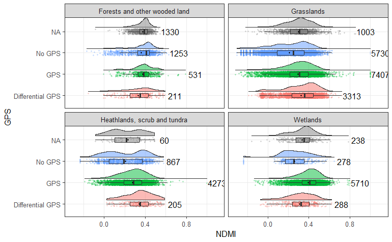

```r
ggplot(data = db_resurv_RS_short %>%
         # Keep only forests, grasslands, shrublands and wetlands
         filter(EUNISa_1 %in% c("T", "R", "S", "Q")) %>%
         filter(S2_data == T | Landsat_data == T ) %>%
         mutate(GPS = ifelse(
           `Location method` == "Location with differential GPS",
           "Differential GPS",
           ifelse(`Location method` == "Location with GPS", "GPS",
                  "No GPS"))),
       aes(x = GPS, y = NDMI, fill = GPS)) +
  geom_flat_violin(position = position_nudge(x = 0.2, y = 0), alpha = 0.5) +
  geom_point(aes(y = NDMI, color = GPS),
             position = position_jitterdodge(jitter.width = 0.25,
                                             dodge.width = 0.25),
             size = 0.5, alpha = 0.25) +
  geom_boxplot(width = 0.2, outlier.shape = NA, alpha = 0.5,
               position = position_dodge(width = 0.25)) +
  stat_summary(fun.y=mean, geom="point", shape = 20, size = 1,
               position = position_dodge(width = 0.25)) +
  stat_summary(fun.data = function(x) data.frame(y = max(x) + 0.1,
                                                 label = length(x)),
               geom = "text", aes(label = ..label..), vjust = 0.5,
               position = position_dodge(width = 0.25)) +
  labs(y = "NDMI", x = "GPS") +
  guides(fill = FALSE, color = FALSE) +
  theme_bw() + coord_flip() + facet_wrap(~ EUNISa_1_descr, nrow = 2)
ggsave(
  here("output", "figures", "NDMI_comp_GPS_diff.tiff"),
  width = 29.7, height = 21, units = "cm", dpi = 300)
```

# Plots Halle

## Points Cordillera

### Read and merge RS data

Read sheets from Excel file sent by Gonzalo (and edited by me to create new sheets). Rename identifiers (Codigo and Plot_ID to id to be able to bind rows of both datasets).

```r
cordi1 <- read_excel(
  here("data", "edited","NDVI_NDMI_Pastizales_Bosques 2_AV.xlsx"),
  sheet = "pastizal_AV") %>%
  rename(id = "Releve_num") %>% mutate(id = as.character(id))
cordi2 <- read_excel(
  here("data", "edited","NDVI_NDMI_Pastizales_Bosques_AV.xlsx"),
  sheet = "bosque_AV") %>%
  rename(id = "Plot_ID")
```

Merge both datasets and get max NDVI and NDMI for each point:

```r
cordi <- bind_rows(cordi1, cordi2) %>% select(-date, -mes) %>%
  group_by(id) %>%
  summarise(max_NDVI = max(NDVI, na.rm = TRUE),
            max_NDMI = max(NDMI, na.rm = TRUE))
```

### Read and merge shapefiles to get vegetation / habitat info

```r
alpine_grasslands <- st_read(
  "C:/GIS/MOTIVATE/shapefiles/EVEREST/AlpineGrasslands_WGS84.shp") %>%
  rename(id = "Releve_num", hab = "Hábitat") %>% select (id, hab) %>%
  mutate(longitude = st_coordinates(geometry)[, 1],
         latitude = st_coordinates(geometry)[, 2]) %>%
  as_tibble() %>%
  mutate(id = as.character(id))
vegetation_types <- st_read(
  "C:/GIS/MOTIVATE/shapefiles/EVEREST/VegetationTypes_WGS84.shp") %>%
  rename(id = "Plot_ID", hab = "Vegetation") %>% select(id, hab) %>%
  mutate(longitude = st_coordinates(geometry)[, 1],
         latitude = st_coordinates(geometry)[, 2]) %>%
  as_tibble()
```

```r
habitats <- bind_rows(alpine_grasslands, vegetation_types)
```

### Merge RS and habitat data

```r
cordi <- habitats %>%
  left_join(cordi)
```

See the different info on hab:

```r
cordi %>% distinct(hab)
```

| hab |
| --- |
| Pastizal alpino |
| Cervunal |
| Suelo pedregoso crioturbado |
| Pastizal en claro de matorral poco pastado |
| Pastizal alpino en zona de nevero |
| Pastizal en suelo crioturbado, pedregoso |
| NA |
| Pastizal alpino en suelo crioturbado |
| Pastizal alpino pedregoso |
| Pastizal posiblemente pastado |

[output cut: 27 more lines]

Assign to EUNIS level 1:

```r
cordi <- cordi %>%
  mutate(EUNIS_1 = case_when(hab = str_detect(hab, "Pastizal|Cervunal|grassland|meadow") ~ "R",
                             hab = str_detect(hab, "forest") ~ "T",
                             hab = str_detect(hab, "Scrub|scrub|Shrubland|shrubland|shrub|Heathland") ~ "S",
                             hab = str_detect(hab, "Suelo") ~ "U",
                             TRUE ~ NA_character_))
```

### Plots NDVI and NDMI

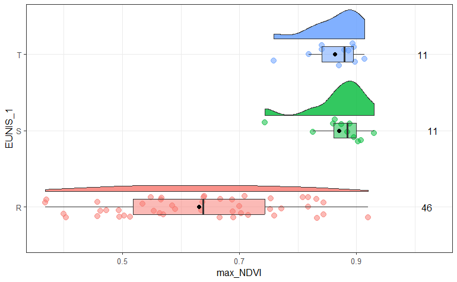

```r
ggplot(data = cordi %>% filter(!is.na(max_NDVI)) %>%
         # Keep only forests, grasslands, shrublands and wetlands
         filter(EUNIS_1 %in% c("T", "R", "S", "Q")),
       aes(x = EUNIS_1, y = max_NDVI, fill = EUNIS_1)) +
  geom_flat_violin(position = position_nudge(x = 0.2, y = 0), alpha = 0.8) +
  geom_point(aes(y = max_NDVI, color = EUNIS_1),
             position = position_jitter(width = 0.15), size = 3,
             alpha = 0.5) +
  geom_boxplot(width = 0.2, outlier.shape = NA, alpha = 0.5) +
  stat_summary(fun.y=mean, geom="point", shape = 20, size = 3) +
  stat_summary(fun.data = function(x) data.frame(y = max(x) + 0.1,
                                                 label = length(x)),
               geom = "text", aes(label = ..label..), vjust = 0.5) +
  guides(fill = FALSE, color = FALSE) + theme_bw() + coord_flip()
ggsave(here("output", "figures", "cordi_NDVI.tiff"),
       width = 21, height = 29.7, units = "cm", dpi = 300)
```

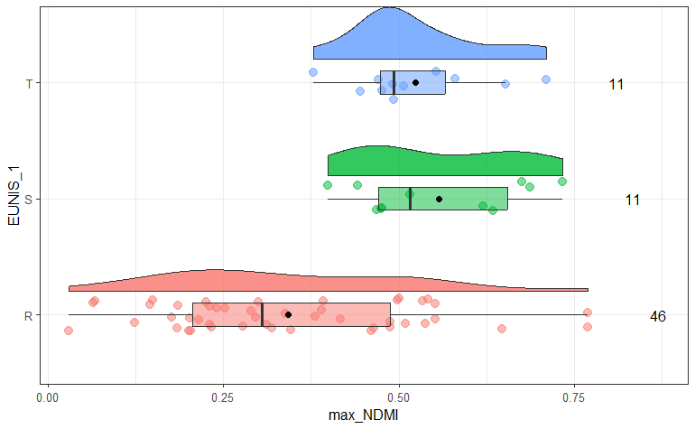

```r
ggplot(data = cordi %>% filter(!is.na(max_NDMI)) %>%
         # Keep only forests, grasslands, shrublands and wetlands
         filter(EUNIS_1 %in% c("T", "R", "S", "Q")),
       aes(x = EUNIS_1, y = max_NDMI, fill = EUNIS_1)) +
  geom_flat_violin(position = position_nudge(x = 0.2, y = 0), alpha = 0.8) +
  geom_point(aes(y = max_NDMI, color = EUNIS_1),
             position = position_jitter(width = 0.15), size = 3,
             alpha = 0.5) +
  geom_boxplot(width = 0.2, outlier.shape = NA, alpha = 0.5) +
  stat_summary(fun.y=mean, geom="point", shape = 20, size = 3) +
  stat_summary(fun.data = function(x) data.frame(y = max(x) + 0.1,
                                                 label = length(x)),
               geom = "text", aes(label = ..label..), vjust = 0.5) +
  guides(fill = FALSE, color = FALSE) + theme_bw() + coord_flip()
ggsave(here("output", "figures", "cordi_NDMI.tiff"),
       width = 21, height = 29.7, units = "cm", dpi = 300)
```

### Maps

```r
# Load world boundaries
world <- ne_countries(scale = "medium", returnclass = "sf")
```

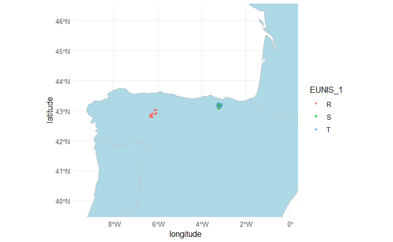

```r
# Calculate the extent of the points
points_cordi_extent <- cordi %>% filter(EUNIS_1 %in% c("T", "R", "S", "Q")) %>%
  summarise(lon_min = min(longitude, na.rm = TRUE),
            lon_max = max(longitude, na.rm = TRUE),
            lat_min = min(latitude, na.rm = TRUE),
            lat_max = max(latitude, na.rm = TRUE))

# Add padding to the extent (adjust as needed)
padding <- 3  # Adjust padding to your preference
x_limits <- c(points_cordi_extent$lon_min - padding,
              points_cordi_extent$lon_max + padding)
y_limits <- c(points_cordi_extent$lat_min - padding,
              points_cordi_extent$lat_max + padding)

# Create the zoomed map
ggplot() +
  geom_sf(data = world, fill = "lightblue", color = "gray") +
  geom_point(data = cordi %>% filter(EUNIS_1 %in% c("T", "R", "S", "Q")),
             aes(x = longitude, y = latitude, color = EUNIS_1),
             size = 1) +
  coord_sf(xlim = x_limits, ylim = y_limits) +
  theme_minimal()
```

## Points differential GPS

### Maps

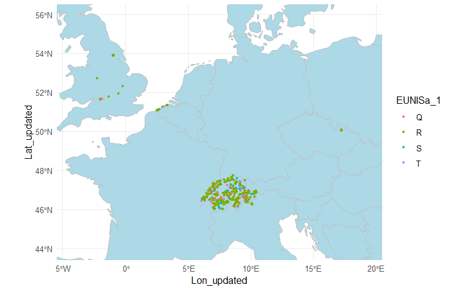

```r
# Calculate the extent of the points
points_GPS_extent <- db_resurv_RS_short %>%
  filter(EUNISa_1 %in% c("T", "R", "S", "Q")) %>%
  filter(S2_data == T | Landsat_data == T ) %>%
  filter(`Location method` == "Location with differential GPS") %>%
  summarise(lon_min = min(Lon_updated, na.rm = TRUE),
            lon_max = max(Lon_updated, na.rm = TRUE),
            lat_min = min(Lat_updated, na.rm = TRUE),
            lat_max = max(Lat_updated, na.rm = TRUE))

# Add padding to the extent (adjust as needed)
padding <- 2  # Adjust padding to your preference
x_limits <- c(points_GPS_extent$lon_min - padding,
              points_GPS_extent$lon_max + padding)
y_limits <- c(points_GPS_extent$lat_min - padding,
              points_GPS_extent$lat_max + padding)

# Create the zoomed map
ggplot() +
  geom_sf(data = world, fill = "lightblue", color = "gray") +
  geom_point(data = db_resurv_RS_short %>%
               filter(EUNISa_1 %in% c("T", "R", "S", "Q")) %>%
               filter(S2_data == T | Landsat_data == T ) %>%
               filter(`Location method` == "Location with differential GPS"),
             aes(x = Lon_updated, y = Lat_updated, color = EUNISa_1),
             size = 1) +
  coord_sf(xlim = x_limits, ylim = y_limits) +
  theme_minimal()
```

Number of differential GPS points by Country:

```r
db_resurv_RS_short %>%
  filter(EUNISa_1 %in% c("T", "R", "S", "Q")) %>%
  filter(S2_data == T | Landsat_data == T ) %>%
  filter(`Location method` == "Location with differential GPS") %>%
  count(Country)
```

| Country | n |
| --- | --- |
| Belgium | 12 |
| Czech Republic | 127 |
| Switzerland | 1769 |
| United Kingdom | 2109 |

## Points ReSurvey

### Maps

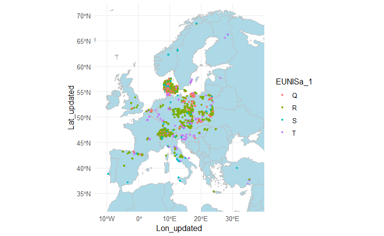

```r
# Calculate the extent of the points
points_resurvey_extent <- db_resurv_RS_short %>%
  filter(EUNISa_1 %in% c("T", "R", "S", "Q")) %>%
  filter(S2_data == T | Landsat_data == T ) %>%
  summarise(lon_min = min(Lon_updated, na.rm = TRUE),
            lon_max = max(Lon_updated, na.rm = TRUE),
            lat_min = min(Lat_updated, na.rm = TRUE),
            lat_max = max(Lat_updated, na.rm = TRUE))

# Add padding to the extent (adjust as needed)
padding <- 2  # Adjust padding to your preference
x_limits <- c(points_resurvey_extent$lon_min - padding,
              points_resurvey_extent$lon_max + padding)
y_limits <- c(points_resurvey_extent$lat_min - padding,
              points_resurvey_extent$lat_max + padding)

# Create the zoomed map
ggplot() +
  geom_sf(data = world, fill = "lightblue", color = "gray") +
  geom_point(data = db_resurv_RS_short %>%
               filter(EUNISa_1 %in% c("T", "R", "S", "Q")) %>%
               filter(S2_data == T | Landsat_data == T ),
             aes(x = Lon_updated, y = Lat_updated, color = EUNISa_1),
             size = 1) +
  coord_sf(xlim = x_limits, ylim = y_limits) +
  theme_minimal()
```

Number of ReSurvey points by Country:

```r
db_resurv_RS_short %>%
  filter(EUNISa_1 %in% c("T", "R", "S", "Q")) %>%
  filter(S2_data == T | Landsat_data == T ) %>%
  count(Country)
```

| Country | n |
| --- | --- |
| Austria | 554 |
| Belgium | 228 |
| Czech Republic | 2860 |
| Denmark | 15717 |
| Finland | 198 |
| France | 166 |
| Germany | 2155 |
| Greece | 19 |
| Hungary | 975 |
| Italy | 740 |

[output cut: 12 more lines]

## Join

```r
points_halle <- bind_rows(
  cordi %>% filter(EUNIS_1 %in% c("T", "R", "S", "Q")) %>%
    select(longitude, latitude, max_NDVI, max_NDMI, EUNIS_1) %>%
    rename(NDVI = max_NDVI, NDMI = max_NDMI, EUNIS = EUNIS_1) %>%
    mutate(point_type = "Cordillera"),
  db_resurv_RS_short %>%
    filter(EUNISa_1 %in% c("T", "R", "S", "Q")) %>%
    filter(S2_data == T | Landsat_data == T ) %>%
    filter(`Location method` == "Location with differential GPS") %>%
    select(Lon_updated, Lat_updated, NDVI, NDMI, EUNISa_1) %>%
    rename(longitude = Lon_updated, latitude = Lat_updated,
           EUNIS = EUNISa_1) %>%
    mutate(point_type = "ReSurvey differential GPS"),
  db_resurv_RS_short %>%
    filter(EUNISa_1 %in% c("T", "R", "S", "Q")) %>%
    filter(S2_data == T | Landsat_data == T ) %>%
    select(Lon_updated, Lat_updated, NDVI, NDMI, EUNISa_1) %>%
    rename(longitude = Lon_updated, latitude = Lat_updated,
           EUNIS = EUNISa_1) %>%
    mutate(point_type = "ReSurvey")
)
```

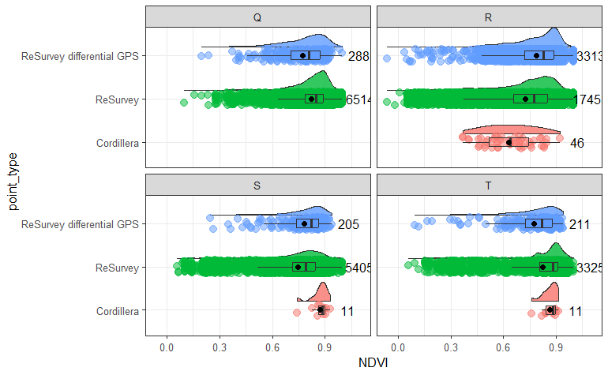

```r
ggplot(data = points_halle,
       aes(x = point_type, y = NDVI, fill = point_type)) +
  geom_flat_violin(position = position_nudge(x = 0.2, y = 0), alpha = 0.8) +
  geom_point(aes(y = NDVI, color = point_type),
             position = position_jitter(width = 0.15), size = 3,
             alpha = 0.5) +
  geom_boxplot(width = 0.2, outlier.shape = NA, alpha = 0.5) +
  stat_summary(fun.y=mean, geom="point", shape = 20, size = 3) +
  stat_summary(fun.data = function(x) data.frame(y = max(x) + 0.1,
                                                 label = length(x)),
               geom = "text", aes(label = ..label..), vjust = 0.5) +
  guides(fill = FALSE, color = FALSE) + theme_bw() + coord_flip() +
  facet_wrap(~ EUNIS)
```

Create shapefile:

```r
st_write(st_as_sf(points_halle, coords = c("longitude", "latitude"),
                  crs = 4326),
         here("..", "..", "..", "GIS", "MOTIVATE", "shapefiles",
              "points_halle.shp"))
```

```
Writing layer `points_halle' to data source
  `C:/Users/jimenezalfaro/OneDrive - Universidad de Oviedo/IMIB/Analyses/MOTIVATE/MOTIVATE_validation/../../../GIS/MOTIVATE/shapefiles/points_halle.shp' using driver `ESRI Shapefile'
Writing 36782 features with 4 fields and geometry type Point.
```

# HERE: fiddling with map in ArcGIS Pro

# LATER: Rules based on CH

Points that are probably wrong / need to be investigated based on CH and habitat types.

CH > 8 m and EUNIS is not T.

```r
db_resurv_RS_short %>%
  filter(canopy_height > 8 & EUNISa_1 != "T") %>%
  count(EUNISa_1_descr) %>%
  add_row(EUNISa_1_descr = "Total", n = sum(.$n))
```

| EUNISa_1_descr | n |
| --- | --- |
| Grasslands | 3195 |
| Heathlands, scrub and tundra | 1000 |
| Wetlands | 613 |
| Total | 4808 |

CH > 5 m and EUNIS is S.

```r
nrow(db_resurv_RS_short %>% filter(canopy_height > 5 & EUNISa_1 == "S"))
```

```
[1] 1806
```

CH > 2 m and EUNIS is R or Q.

```r
nrow(db_resurv_RS_short %>%
       filter(canopy_height > 2 & (EUNISa_1 == "R" | EUNISa_1 == "Q")))
```

```
[1] 8669
```

## First try at wrong points

For terrestrial natural habitats (T, R, S, Q, N)

```r
db_resurv_RS_short_terrestrial <- db_resurv_RS_short %>%
  filter(EUNISa_1 %in% c("T", "R", "S", "Q", "N"))
nrow(db_resurv_RS_short)
```

[output not shown]

```r
nrow(db_resurv_RS_short %>% filter(!is.na(EUNISa_1)))
```

[output not shown]

```r
nrow(db_resurv_RS_short_terrestrial)
```

```
[1] 188807
```

```r
wrong_pts <- db_resurv_RS_short_terrestrial %>%
  filter(
    # Forest and CH < 8
    (canopy_height < 8 & EUNISa_1 == "T") |
      # Shrubland and CH > 5
      (canopy_height > 5 & EUNISa_1 == "S") |
      # Grassland and CH > 2
      (canopy_height > 2 & EUNISa_1 == "R")
           )
nrow(wrong_pts)/nrow(db_resurv_RS_short_terrestrial)
```

```
[1] 0.07435635
```